# (TMDB 5000 Movie Dataset)

## by (Mo3az Elsokary)

## Preliminary Wrangling

> This data set contains information about 10,000 movies collected from The Movie Database (TMDb), including popularity, budget, revenue, director, vote average, release year and more.

```python
# import all packages and set plots to be embedded inline
import numpy as np
import pandas as pd
import matplotlib.pyplot as plt
import matplotlib.gridspec as gridspec
import seaborn as sb
%matplotlib inline
pd.set_option('display.max_columns',None)
```

## Data Wrangling

#### 1 - General Properties

```python
# Load data
df = pd.read_csv("tmdb-movies.csv")
df
```

|  | id | imdb_id | popularity | budget | revenue | original_title | cast | homepage | director | tagline | keywords | overview | runtime | genres | production_companies | release_date | vote_count | vote_average | release_year | budget_adj | revenue_adj |
| --- | --- | --- | --- | --- | --- | --- | --- | --- | --- | --- | --- | --- | --- | --- | --- | --- | --- | --- | --- | --- | --- |
| 0 | 135397 | tt0369610 | 32.985763 | 150000000 | 1513528810 | Jurassic World | Chris Pratt\|Bryce Dallas Howard\|Irrfan Khan\|Vi... | http://www.jurassicworld.com/ | Colin Trevorrow | The park is open. | monster\|dna\|tyrannosaurus rex\|velociraptor\|island | Twenty-two years after the events of Jurassic ... | 124 | Action\|Adventure\|Science Fiction\|Thriller | Universal Studios\|Amblin Entertainment\|Legenda... | 6/9/15 | 5562 | 6.5 | 2015 | 1.379999e+08 | 1.392446e+09 |
| 1 | 76341 | tt1392190 | 28.419936 | 150000000 | 378436354 | Mad Max: Fury Road | Tom Hardy\|Charlize Theron\|Hugh Keays-Byrne\|Nic... | http://www.madmaxmovie.com/ | George Miller | What a Lovely Day. | future\|chase\|post-apocalyptic\|dystopia\|australia | An apocalyptic story set in the furthest reach... | 120 | Action\|Adventure\|Science Fiction\|Thriller | Village Roadshow Pictures\|Kennedy Miller Produ... | 5/13/15 | 6185 | 7.1 | 2015 | 1.379999e+08 | 3.481613e+08 |
| 2 | 262500 | tt2908446 | 13.112507 | 110000000 | 295238201 | Insurgent | Shailene Woodley\|Theo James\|Kate Winslet\|Ansel... | http://www.thedivergentseries.movie/#insurgent | Robert Schwentke | One Choice Can Destroy You | based on novel\|revolution\|dystopia\|sequel\|dyst... | Beatrice Prior must confront her inner demons ... | 119 | Adventure\|Science Fiction\|Thriller | Summit Entertainment\|Mandeville Films\|Red Wago... | 3/18/15 | 2480 | 6.3 | 2015 | 1.012000e+08 | 2.716190e+08 |
| 3 | 140607 | tt2488496 | 11.173104 | 200000000 | 2068178225 | Star Wars: The Force Awakens | Harrison Ford\|Mark Hamill\|Carrie Fisher\|Adam D... | http://www.starwars.com/films/star-wars-episod... | J.J. Abrams | Every generation has a story. | android\|spaceship\|jedi\|space opera\|3d | Thirty years after defeating the Galactic Empi... | 136 | Action\|Adventure\|Science Fiction\|Fantasy | Lucasfilm\|Truenorth Productions\|Bad Robot | 12/15/15 | 5292 | 7.5 | 2015 | 1.839999e+08 | 1.902723e+09 |
| 4 | 168259 | tt2820852 | 9.335014 | 190000000 | 1506249360 | Furious 7 | Vin Diesel\|Paul Walker\|Jason Statham\|Michelle ... | http://www.furious7.com/ | James Wan | Vengeance Hits Home | car race\|speed\|revenge\|suspense\|car | Deckard Shaw seeks revenge against Dominic Tor... | 137 | Action\|Crime\|Thriller | Universal Pictures\|Original Film\|Media Rights ... | 4/1/15 | 2947 | 7.3 | 2015 | 1.747999e+08 | 1.385749e+09 |
| ... | ... | ... | ... | ... | ... | ... | ... | ... | ... | ... | ... | ... | ... | ... | ... | ... | ... | ... | ... | ... | ... |
| 10861 | 21 | tt0060371 | 0.080598 | 0 | 0 | The Endless Summer | Michael Hynson\|Robert August\|Lord 'Tally Ho' B... | NaN | Bruce Brown | NaN | surfer\|surfboard\|surfing | The Endless Summer, by Bruce Brown, is one of ... | 95 | Documentary | Bruce Brown Films | 6/15/66 | 11 | 7.4 | 1966 | 0.000000e+00 | 0.000000e+00 |
| 10862 | 20379 | tt0060472 | 0.065543 | 0 | 0 | Grand Prix | James Garner\|Eva Marie Saint\|Yves Montand\|Tosh... | NaN | John Frankenheimer | Cinerama sweeps YOU into a drama of speed and ... | car race\|racing\|formula 1 | Grand Prix driver Pete Aron is fired by his te... | 176 | Action\|Adventure\|Drama | Cherokee Productions\|Joel Productions\|Douglas ... | 12/21/66 | 20 | 5.7 | 1966 | 0.000000e+00 | 0.000000e+00 |
| 10863 | 39768 | tt0060161 | 0.065141 | 0 | 0 | Beregis Avtomobilya | Innokentiy Smoktunovskiy\|Oleg Efremov\|Georgi Z... | NaN | Eldar Ryazanov | NaN | car\|trolley\|stealing car | An insurance agent who moonlights as a carthie... | 94 | Mystery\|Comedy | Mosfilm | 1/1/66 | 11 | 6.5 | 1966 | 0.000000e+00 | 0.000000e+00 |
| 10864 | 21449 | tt0061177 | 0.064317 | 0 | 0 | What's Up, Tiger Lily? | Tatsuya Mihashi\|Akiko Wakabayashi\|Mie Hama\|Joh... | NaN | Woody Allen | WOODY ALLEN STRIKES BACK! | spoof | In comic Woody Allen's film debut, he took the... | 80 | Action\|Comedy | Benedict Pictures Corp. | 11/2/66 | 22 | 5.4 | 1966 | 0.000000e+00 | 0.000000e+00 |
| 10865 | 22293 | tt0060666 | 0.035919 | 19000 | 0 | Manos: The Hands of Fate | Harold P. Warren\|Tom Neyman\|John Reynolds\|Dian... | NaN | Harold P. Warren | It's Shocking! It's Beyond Your Imagination! | fire\|gun\|drive\|sacrifice\|flashlight | A family gets lost on the road and stumbles up... | 74 | Horror | Norm-Iris | 11/15/66 | 15 | 1.5 | 1966 | 1.276423e+05 | 0.000000e+00 |

10866 rows × 21 columns

```python
# Shape of the dataframe
df.info()
```

```
<class 'pandas.core.frame.DataFrame'>
RangeIndex: 10866 entries, 0 to 10865
Data columns (total 21 columns):
 #   Column                Non-Null Count  Dtype
---  ------                --------------  -----
 0   id                    10866 non-null  int64
 1   imdb_id               10856 non-null  object
 2   popularity            10866 non-null  float64
 3   budget                10866 non-null  int64
 4   revenue               10866 non-null  int64
 5   original_title        10866 non-null  object
 6   cast                  10790 non-null  object
 7   homepage              2936 non-null   object
 8   director              10822 non-null  object
 9   tagline               8042 non-null   object
 10  keywords              9373 non-null   object
 11  overview              10862 non-null  object
 12  runtime               10866 non-null  int64
 13  genres                10843 non-null  object
 14  production_companies  9836 non-null   object
 15  release_date          10866 non-null  object
 16  vote_count            10866 non-null  int64
 17  vote_average          10866 non-null  float64
 18  release_year          10866 non-null  int64
 19  budget_adj            10866 non-null  float64
 20  revenue_adj           10866 non-null  float64
dtypes: float64(4), int64(6), object(11)
memory usage: 1.7+ MB
```

```python
# Check for duplicated values
df [df.duplicated()==True]
```

|  | id | imdb_id | popularity | budget | revenue | original_title | cast | homepage | director | tagline | keywords | overview | runtime | genres | production_companies | release_date | vote_count | vote_average | release_year | budget_adj | revenue_adj |
| --- | --- | --- | --- | --- | --- | --- | --- | --- | --- | --- | --- | --- | --- | --- | --- | --- | --- | --- | --- | --- | --- |
| 2090 | 42194 | tt0411951 | 0.59643 | 30000000 | 967000 | TEKKEN | Jon Foo\|Kelly Overton\|Cary-Hiroyuki Tagawa\|Ian... | NaN | Dwight H. Little | Survival is no game | martial arts\|dystopia\|based on video game\|mart... | In the year of 2039, after World Wars destroy ... | 92 | Crime\|Drama\|Action\|Thriller\|Science Fiction | Namco\|Light Song Films | 3/20/10 | 110 | 5.0 | 2010 | 30000000.0 | 967000.0 |

```python
# Exploring some statistics about data
df.describe()
```

|  | id | popularity | budget | revenue | runtime | vote_count | vote_average | release_year | budget_adj | revenue_adj |
| --- | --- | --- | --- | --- | --- | --- | --- | --- | --- | --- |
| count | 10866.000000 | 10866.000000 | 1.086600e+04 | 1.086600e+04 | 10866.000000 | 10866.000000 | 10866.000000 | 10866.000000 | 1.086600e+04 | 1.086600e+04 |
| mean | 66064.177434 | 0.646441 | 1.462570e+07 | 3.982332e+07 | 102.070863 | 217.389748 | 5.974922 | 2001.322658 | 1.755104e+07 | 5.136436e+07 |
| std | 92130.136561 | 1.000185 | 3.091321e+07 | 1.170035e+08 | 31.381405 | 575.619058 | 0.935142 | 12.812941 | 3.430616e+07 | 1.446325e+08 |
| min | 5.000000 | 0.000065 | 0.000000e+00 | 0.000000e+00 | 0.000000 | 10.000000 | 1.500000 | 1960.000000 | 0.000000e+00 | 0.000000e+00 |
| 25% | 10596.250000 | 0.207583 | 0.000000e+00 | 0.000000e+00 | 90.000000 | 17.000000 | 5.400000 | 1995.000000 | 0.000000e+00 | 0.000000e+00 |
| 50% | 20669.000000 | 0.383856 | 0.000000e+00 | 0.000000e+00 | 99.000000 | 38.000000 | 6.000000 | 2006.000000 | 0.000000e+00 | 0.000000e+00 |
| 75% | 75610.000000 | 0.713817 | 1.500000e+07 | 2.400000e+07 | 111.000000 | 145.750000 | 6.600000 | 2011.000000 | 2.085325e+07 | 3.369710e+07 |
| max | 417859.000000 | 32.985763 | 4.250000e+08 | 2.781506e+09 | 900.000000 | 9767.000000 | 9.200000 | 2015.000000 | 4.250000e+08 | 2.827124e+09 |

```python
# columns correlation
df.corr()
```

|  | id | popularity | budget | revenue | runtime | vote_count | vote_average | release_year | budget_adj | revenue_adj |
| --- | --- | --- | --- | --- | --- | --- | --- | --- | --- | --- |
| id | 1.000000 | -0.014350 | -0.141351 | -0.099227 | -0.088360 | -0.035551 | -0.058363 | 0.511364 | -0.189015 | -0.138477 |
| popularity | -0.014350 | 1.000000 | 0.545472 | 0.663358 | 0.139033 | 0.800828 | 0.209511 | 0.089801 | 0.513550 | 0.609083 |
| budget | -0.141351 | 0.545472 | 1.000000 | 0.734901 | 0.191283 | 0.632702 | 0.081014 | 0.115931 | 0.968963 | 0.622505 |
| revenue | -0.099227 | 0.663358 | 0.734901 | 1.000000 | 0.162838 | 0.791175 | 0.172564 | 0.057048 | 0.706427 | 0.919110 |
| runtime | -0.088360 | 0.139033 | 0.191283 | 0.162838 | 1.000000 | 0.163278 | 0.156835 | -0.117204 | 0.221114 | 0.175676 |
| vote_count | -0.035551 | 0.800828 | 0.632702 | 0.791175 | 0.163278 | 1.000000 | 0.253823 | 0.107948 | 0.587051 | 0.707942 |
| vote_average | -0.058363 | 0.209511 | 0.081014 | 0.172564 | 0.156835 | 0.253823 | 1.000000 | -0.117632 | 0.093039 | 0.193085 |
| release_year | 0.511364 | 0.089801 | 0.115931 | 0.057048 | -0.117204 | 0.107948 | -0.117632 | 1.000000 | 0.016793 | -0.066256 |
| budget_adj | -0.189015 | 0.513550 | 0.968963 | 0.706427 | 0.221114 | 0.587051 | 0.093039 | 0.016793 | 1.000000 | 0.646607 |
| revenue_adj | -0.138477 | 0.609083 | 0.622505 | 0.919110 | 0.175676 | 0.707942 | 0.193085 | -0.066256 | 0.646607 | 1.000000 |

### Data Cleaning

```python
# Remove columns thats we don't need in the analysis
df.drop(['id', 'imdb_id', 'budget', 'revenue', 'original_title', 'homepage', 'tagline', 'keywords', 'overview',
       'runtime','release_date','cast','genres','production_companies','vote_count'],axis=1, inplace=True)
```

```python
# Remove null values
df.dropna(inplace=True)
```

```python
# Check for null values
df.isnull().sum()
```

```
popularity      0
director        0
vote_average    0
release_year    0
budget_adj      0
revenue_adj     0
dtype: int64
```

```python
# Remove the missing values in both two columns revenue_adj and budget_adj
df_zeroes=df.query('revenue_adj == 0 & budget_adj == 0')
df.drop(df_zeroes.index,inplace=True)
```

```python
# The duplicated row
df[df.duplicated()]
```

|  | popularity | director | vote_average | release_year | budget_adj | revenue_adj |
| --- | --- | --- | --- | --- | --- | --- |
| 2090 | 0.59643 | Dwight H. Little | 5.0 | 2010 | 30000000.0 | 967000.0 |

```python
# Remove the duplicated row
df.drop_duplicates(inplace=True)
```

```python
# Rename column
df.rename({'director':'directors'},axis=1,inplace=True)
```

```python
#sCheck the shape of the dataframe again
df.shape
```

```
(6160, 6)
```

> still there is some missing data in two major columns [ revenue_adj and budget_adj ] so that we should handle it wisely :

> > first i created a new column called income to represent the ratio between the revenue_adj and budget_adj and extracted the median that will use to extract the missing values ; then used np.where function to replace the missing values.

```python
# create a copy of dataframe that haven't missing values in any this columns : revenue_adj and budget_adj
df_nonzeroes=df.query('revenue_adj != 0 & budget_adj != 0')
```

```python
# Find the ratio between revenues and budget
df_nonzeroes['income'] = df_nonzeroes['revenue_adj']/df_nonzeroes['budget_adj']
# Find some statistics about it
df_nonzeroes['income'].describe()
```

```
count    3.853000e+03
mean     2.981179e+02
std      1.644469e+04
min      2.400000e-07
25%      8.764363e-01
50%      2.119489e+00
75%      4.210730e+00
max      1.018619e+06
Name: income, dtype: float64
```

```python
df_nonzeroes['income'].median()
```

```
2.1194886071428574
```

```python
# Find the rows that have missing values one this columns : revenue_adj and budget_adj
df.query('revenue_adj == 0 | budget_adj == 0').shape
```

```
(2307, 6)
```

```python
# fill in the misin values
df["revenue_adj"].where(df["revenue_adj"] != 0 , df["budget_adj"] * df_nonzeroes['income'].median(), inplace = True)
df["budget_adj"].where(df["budget_adj"] != 0 , df["revenue_adj"] / df_nonzeroes['income'].median(), inplace = True)
```

```python
# Check again
df.query('revenue_adj == 0 | budget_adj == 0').shape
# Now it's clear
```

```
(0, 6)
```

```python
# Our dataframe that will work on
df.reset_index(drop=True,inplace=True)
df
```

|  | popularity | directors | vote_average | release_year | budget_adj | revenue_adj |
| --- | --- | --- | --- | --- | --- | --- |
| 0 | 32.985763 | Colin Trevorrow | 6.5 | 2015 | 1.379999e+08 | 1.392446e+09 |
| 1 | 28.419936 | George Miller | 7.1 | 2015 | 1.379999e+08 | 3.481613e+08 |
| 2 | 13.112507 | Robert Schwentke | 6.3 | 2015 | 1.012000e+08 | 2.716190e+08 |
| 3 | 11.173104 | J.J. Abrams | 7.5 | 2015 | 1.839999e+08 | 1.902723e+09 |
| 4 | 9.335014 | James Wan | 7.3 | 2015 | 1.747999e+08 | 1.385749e+09 |
| ... | ... | ... | ... | ... | ... | ... |
| 6155 | 0.299911 | Robert Wise | 7.0 | 1966 | 8.061618e+07 | 1.343603e+08 |
| 6156 | 0.264925 | Monte Hellman | 5.5 | 1966 | 5.038511e+05 | 1.067907e+06 |
| 6157 | 0.207257 | Richard Fleischer | 6.7 | 1966 | 3.436265e+07 | 8.061618e+07 |
| 6158 | 0.141026 | Alan Rafkin | 6.1 | 1966 | 4.702610e+06 | 9.967129e+06 |
| 6159 | 0.035919 | Harold P. Warren | 1.5 | 1966 | 1.276423e+05 | 2.705364e+05 |

6160 rows × 6 columns

## Making another special dataframe specially for directors

> first : we will split the directors coloumn to handle those values have more one director for the movie

```python
# split the directors column to create a column that have one director
data = df.join(df.directors.str.strip('|').str.split('|',expand=True).stack()
               .reset_index(level=1,drop=True).rename('director')).reset_index(drop=True)
data
```

|  | popularity | directors | vote_average | release_year | budget_adj | revenue_adj | director |
| --- | --- | --- | --- | --- | --- | --- | --- |
| 0 | 32.985763 | Colin Trevorrow | 6.5 | 2015 | 1.379999e+08 | 1.392446e+09 | Colin Trevorrow |
| 1 | 28.419936 | George Miller | 7.1 | 2015 | 1.379999e+08 | 3.481613e+08 | George Miller |
| 2 | 13.112507 | Robert Schwentke | 6.3 | 2015 | 1.012000e+08 | 2.716190e+08 | Robert Schwentke |
| 3 | 11.173104 | J.J. Abrams | 7.5 | 2015 | 1.839999e+08 | 1.902723e+09 | J.J. Abrams |
| 4 | 9.335014 | James Wan | 7.3 | 2015 | 1.747999e+08 | 1.385749e+09 | James Wan |
| ... | ... | ... | ... | ... | ... | ... | ... |
| 6696 | 0.299911 | Robert Wise | 7.0 | 1966 | 8.061618e+07 | 1.343603e+08 | Robert Wise |
| 6697 | 0.264925 | Monte Hellman | 5.5 | 1966 | 5.038511e+05 | 1.067907e+06 | Monte Hellman |
| 6698 | 0.207257 | Richard Fleischer | 6.7 | 1966 | 3.436265e+07 | 8.061618e+07 | Richard Fleischer |
| 6699 | 0.141026 | Alan Rafkin | 6.1 | 1966 | 4.702610e+06 | 9.967129e+06 | Alan Rafkin |
| 6700 | 0.035919 | Harold P. Warren | 1.5 | 1966 | 1.276423e+05 | 2.705364e+05 | Harold P. Warren |

6701 rows × 7 columns

> second : we will deal with the mean of this columns [budget_adj , popularity , vote_average , revenue_adj , release_year].

```python
# the mean adjusted budget by director
mean_director_budget = data.groupby('director').budget_adj.mean()

# the mean popularity by director
mean_director_popularity = data.groupby('director').popularity.mean()

# the mean vote average by director
mean_director_vote = data.groupby('director').vote_average.mean()

#  the mean adjusted revenue by director
mean_director_revenue = data.groupby('director').revenue_adj.mean()

# the mean release year by director
mean_director_release_year = data.groupby('director').release_year.mean()
```

> then : we will make our new dataframe and make two indicies [drirector and numbers] and sort them by budjet_adj .

```python
# Create new dataframe about director by the mean of the other columns
mean_director_data = pd.concat([ mean_director_budget,mean_director_popularity,mean_director_revenue,
                                mean_director_vote, mean_director_release_year],axis=1)
```

```python
mean_director_data["release_year"] = np.round(mean_director_data["release_year"])
mean_director_data["release_year"]=mean_director_data["release_year"].astype(int)
mean_director_data
```

| director | budget_adj | popularity | revenue_adj | vote_average | release_year |
| --- | --- | --- | --- | --- | --- |
| Frédéric Jardin | 2.423495e+06 | 0.434506 | 3.255239e+03 | 5.900000 | 2011 |
| A.R. Murugadoss | 9.216358e+06 | 0.215030 | 7.697178e+07 | 6.900000 | 2008 |
| Aaron Blaise | 1.185353e+08 | 1.653031 | 2.963382e+02 | 6.800000 | 2003 |
| Aaron Harvey | 6.785786e+06 | 1.212003 | 1.438240e+07 | 4.900000 | 2011 |
| Aaron Moorhead | 1.144401e+04 | 0.336755 | 2.425545e+04 | 5.350000 | 2014 |
| ... | ... | ... | ... | ... | ... |
| Ãlex de la Iglesia | 9.402321e+06 | 0.268807 | 1.605553e+07 | 6.166667 | 2007 |
| Ãlvaro de Armiñán | 6.606603e+06 | 0.294762 | 1.400262e+07 | 4.600000 | 2009 |
| Émile Gaudreault | 5.170387e+06 | 0.276911 | 3.593753e+06 | 5.200000 | 2003 |
| Étienne Chatiliez | 1.912487e+07 | 0.064672 | 4.053495e+07 | 7.200000 | 1995 |
| Àlex Pastor | 2.782551e+06 | 0.619369 | 5.897584e+06 | 5.700000 | 2009 |

2958 rows × 5 columns

```python
# The infromation about the new dataframe
mean_director_data.info()
```

```
<class 'pandas.core.frame.DataFrame'>
Index: 2958 entries,  FrÃ©dÃ©ric Jardin to Ã€lex Pastor
Data columns (total 5 columns):
 #   Column        Non-Null Count  Dtype
---  ------        --------------  -----
 0   budget_adj    2958 non-null   float64
 1   popularity    2958 non-null   float64
 2   revenue_adj   2958 non-null   float64
 3   vote_average  2958 non-null   float64
 4   release_year  2958 non-null   int32
dtypes: float64(4), int32(1)
memory usage: 127.1+ KB
```

```python
# Sort the director by budjet_adj
mean_director_data = mean_director_data.sort_values(by=['budget_adj'],ascending=False)
```

```python
# Make mutible index with both numbers and director
mean_director_data = mean_director_data.reset_index()
mean_director_data.set_index([np.arange(1,2959),'director'],inplace=True)
mean_director_data
```

|  | director | budget_adj | popularity | revenue_adj | vote_average | release_year |
| --- | --- | --- | --- | --- | --- | --- |
| 1 | Sngmoo Lee | 4.250000e+08 | 0.250540 | 1.108757e+07 | 6.4 | 2010 |
| 2 | Nathan Greno | 2.600000e+08 | 2.865684 | 5.917949e+08 | 7.3 | 2010 |
| 3 | Darryl F. Zanuck | 2.215444e+08 | 0.804533 | 4.111904e+08 | 6.3 | 1963 |
| 4 | Rouben Mamoulian | 2.215444e+08 | 0.804533 | 4.111904e+08 | 6.3 | 1963 |
| 5 | Joseph L. Mankiewicz | 2.215444e+08 | 0.804533 | 4.111904e+08 | 6.3 | 1963 |
| ... | ... | ... | ... | ... | ... | ... |
| 2954 | Silvio Muccino | 4.300603e+00 | 0.113082 | 9.115080e+00 | 5.1 | 2008 |
| 2955 | Taika Waititi | 3.000000e+00 | 0.028456 | 4.300000e+01 | 7.3 | 2010 |
| 2956 | Ian Fitzgibbon | 2.908194e+00 | 0.228643 | 6.163884e+00 | 6.5 | 2011 |
| 2957 | Dermot Mulroney | 9.693980e-01 | 0.520430 | 1.335831e+03 | 5.3 | 2011 |
| 2958 | Robert Hall | 9.210911e-01 | 0.177102 | 1.952242e+00 | 4.1 | 2014 |

2958 rows × 5 columns

## The Prepared Data

```python
# The whole dataframe
df
```

|  | popularity | directors | vote_average | release_year | budget_adj | revenue_adj |
| --- | --- | --- | --- | --- | --- | --- |
| 0 | 32.985763 | Colin Trevorrow | 6.5 | 2015 | 1.379999e+08 | 1.392446e+09 |
| 1 | 28.419936 | George Miller | 7.1 | 2015 | 1.379999e+08 | 3.481613e+08 |
| 2 | 13.112507 | Robert Schwentke | 6.3 | 2015 | 1.012000e+08 | 2.716190e+08 |
| 3 | 11.173104 | J.J. Abrams | 7.5 | 2015 | 1.839999e+08 | 1.902723e+09 |
| 4 | 9.335014 | James Wan | 7.3 | 2015 | 1.747999e+08 | 1.385749e+09 |
| ... | ... | ... | ... | ... | ... | ... |
| 6155 | 0.299911 | Robert Wise | 7.0 | 1966 | 8.061618e+07 | 1.343603e+08 |
| 6156 | 0.264925 | Monte Hellman | 5.5 | 1966 | 5.038511e+05 | 1.067907e+06 |
| 6157 | 0.207257 | Richard Fleischer | 6.7 | 1966 | 3.436265e+07 | 8.061618e+07 |
| 6158 | 0.141026 | Alan Rafkin | 6.1 | 1966 | 4.702610e+06 | 9.967129e+06 |
| 6159 | 0.035919 | Harold P. Warren | 1.5 | 1966 | 1.276423e+05 | 2.705364e+05 |

6160 rows × 6 columns

```python
# The special one for dealing with directors
mean_director_data
```

|  | director | budget_adj | popularity | revenue_adj | vote_average | release_year |
| --- | --- | --- | --- | --- | --- | --- |
| 1 | Sngmoo Lee | 4.250000e+08 | 0.250540 | 1.108757e+07 | 6.4 | 2010 |
| 2 | Nathan Greno | 2.600000e+08 | 2.865684 | 5.917949e+08 | 7.3 | 2010 |
| 3 | Darryl F. Zanuck | 2.215444e+08 | 0.804533 | 4.111904e+08 | 6.3 | 1963 |
| 4 | Rouben Mamoulian | 2.215444e+08 | 0.804533 | 4.111904e+08 | 6.3 | 1963 |
| 5 | Joseph L. Mankiewicz | 2.215444e+08 | 0.804533 | 4.111904e+08 | 6.3 | 1963 |
| ... | ... | ... | ... | ... | ... | ... |
| 2954 | Silvio Muccino | 4.300603e+00 | 0.113082 | 9.115080e+00 | 5.1 | 2008 |
| 2955 | Taika Waititi | 3.000000e+00 | 0.028456 | 4.300000e+01 | 7.3 | 2010 |
| 2956 | Ian Fitzgibbon | 2.908194e+00 | 0.228643 | 6.163884e+00 | 6.5 | 2011 |
| 2957 | Dermot Mulroney | 9.693980e-01 | 0.520430 | 1.335831e+03 | 5.3 | 2011 |
| 2958 | Robert Hall | 9.210911e-01 | 0.177102 | 1.952242e+00 | 4.1 | 2014 |

2958 rows × 5 columns

### What is/are the main feature(s) of interest in your dataset?

> I'm most interested in figuring out the directors, popularity and revenue_adj.

### What features in the dataset do you think will help support your investigation into your feature(s) of interest?

> i will use the all other columns to answer a lot of questions about the intrested features.

## Univariate Exploration

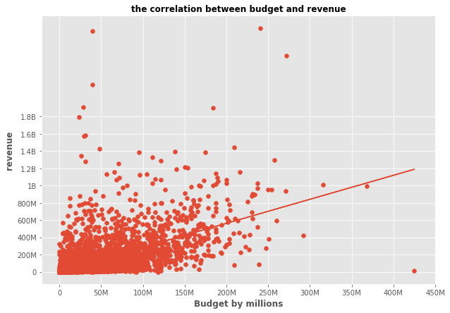

```python
x = df.budget_adj
y = df.revenue_adj
plt.figure(figsize=(10,7))
plt.scatter(x,y)
m,b=np.polyfit(x,y,1)
plt.plot(x,m*x+b)
plt.xticks(np.arange(0,500000000,50000000),['0','50M','100M','150M','200M','250M','300M','350M','400M','450M'])
plt.yticks(np.arange(0,2000000000,200000000),['0','200M','400M','600M','800M','1B','1.2B','1.4B','1.6B','1.8B'])
plt.ylabel('revenue',fontsize=12,fontweight='bold')
plt.xlabel('Budget by millions',fontsize=12,fontweight='bold')
plt.title('the correlation between budget and revenue',fontsize=12,fontweight='bold');
```

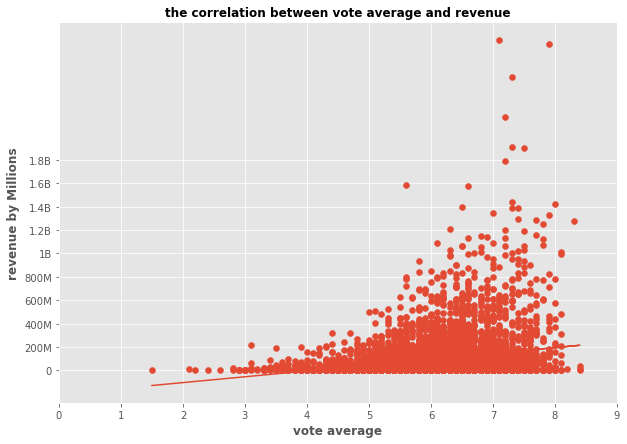

```python
x = df.vote_average
y = df.revenue_adj
plt.figure(figsize=(10,7))
plt.scatter(x,y)
m,b=np.polyfit(x,y,1)
plt.plot(x,m*x+b)
plt.xticks(np.arange(0,10,1))
plt.yticks(np.arange(0,2000000000,200000000),['0','200M','400M','600M','800M','1B','1.2B','1.4B','1.6B','1.8B'])
plt.ylabel('revenue by Millions',fontsize=12,fontweight='bold')
plt.xlabel('vote average',fontsize=12,fontweight='bold')
plt.title('the correlation between vote average and revenue',fontsize=12,fontweight='bold');
```

> By analyzing this figures we can think about some didactions. For example, there are some connection between budget and revenue, vote average and revenue. By the helping of these corrolations we can say that if budget increase, revenue would increase accordingly and higher rating not means higher revenues for most of the movie, it's not standard. and we will see all the correlations in the bivariate secion.

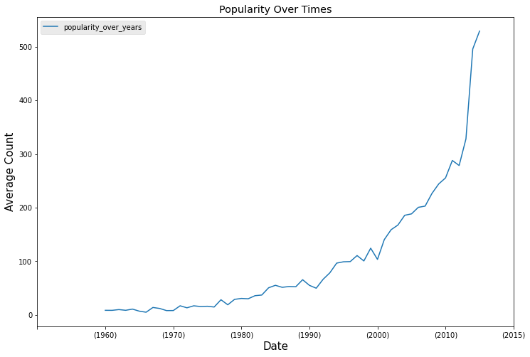

```python
# Plot the popularity over Time
popularity_over_years = df.groupby(df.release_year).popularity.sum()
popularity_over_years.plot( figsize=(12,8),label='popularity_over_years');
plt.style.use('ggplot')
plt.xlabel('Date',fontsize=15)
plt.ylabel('Average Count',fontsize=15)
plt.title('Popularity Over Times')
plt.legend()
locs , labels = plt.xticks()
plt.xticks(locs , ( '','(1960)','(1970)','(1980)','(1990)','(2000)','(2010)','(2015)'));
```

> By analyzing this figures we can say that people loves movies year over year so that popularity and we will see the budget and the revenue in the bivariate section.

```python
# Find the top 20 popularity director
top_20_popularity = mean_director_data.sort_values(by=['popularity'],ascending=False).head(20).reset_index()
top_20_popularity.rename(columns={'level_0':'budget_rank'},inplace=True)
top_20_popularity.sort_values(by=['popularity'],inplace=True)
top_20_popularity
```

|  | budget_rank | director | budget_adj | popularity | revenue_adj | vote_average | release_year |
| --- | --- | --- | --- | --- | --- | --- | --- |
| 19 | 631 | Sam Taylor-Johnson | 3.679998e+07 | 4.710402 | 5.240791e+08 | 5.300000 | 2015 |
| 18 | 2197 | Damien Chazelle | 3.039600e+06 | 4.780419 | 1.288891e+07 | 8.200000 | 2014 |
| 17 | 449 | Alejandro González Iñárritu | 4.788209e+07 | 4.793536 | 2.008489e+08 | 7.050000 | 2010 |
| 16 | 33 | J.J. Abrams | 1.450053e+08 | 4.800957 | 6.829354e+08 | 7.020000 | 2011 |
| 15 | 24 | Pete Docter | 1.601637e+08 | 4.813334 | 7.406167e+08 | 7.633333 | 2008 |
| 14 | 11 | Bob Peterson | 1.778701e+08 | 4.908902 | 7.433371e+08 | 7.600000 | 2009 |
| 13 | 238 | Pierre Coffin | 6.940617e+07 | 5.041612 | 8.387905e+08 | 6.866667 | 2013 |
| 12 | 126 | Don Hall | 9.053098e+07 | 5.058319 | 3.073330e+08 | 7.300000 | 2012 |
| 11 | 29 | Chris Williams | 1.519490e+08 | 5.085896 | 4.572960e+08 | 7.050000 | 2011 |
| 10 | 8 | David Yates | 1.957563e+08 | 5.126634 | 1.044364e+09 | 7.400000 | 2009 |
| 9 | 1744 | Dan Gilroy | 7.829274e+06 | 5.522641 | 3.564366e+07 | 7.600000 | 2014 |
| 8 | 501 | Wes Ball | 4.371854e+07 | 5.553082 | 3.035953e+08 | 6.700000 | 2014 |
| 7 | 652 | Patrick Tatopoulos | 3.557402e+07 | 5.806897 | 9.282500e+07 | 6.200000 | 2009 |
| 6 | 41 | Jennifer Lee | 1.404050e+08 | 6.112766 | 1.192711e+09 | 7.500000 | 2013 |
| 5 | 1373 | Alex Garland | 1.379999e+07 | 6.118847 | 3.391985e+07 | 7.600000 | 2015 |
| 4 | 30 | Alan Taylor | 1.508628e+08 | 6.883129 | 4.272156e+08 | 6.300000 | 2014 |
| 3 | 59 | Christopher Nolan | 1.268367e+08 | 7.695094 | 5.205327e+08 | 7.637500 | 2007 |
| 2 | 1161 | David Leitch | 1.842182e+07 | 11.422751 | 7.252661e+07 | 7.000000 | 2014 |
| 1 | 1157 | Chad Stahelski | 1.842182e+07 | 11.422751 | 7.252661e+07 | 7.000000 | 2014 |
| 0 | 239 | Colin Trevorrow | 6.935612e+07 | 16.696886 | 6.981261e+08 | 6.600000 | 2014 |

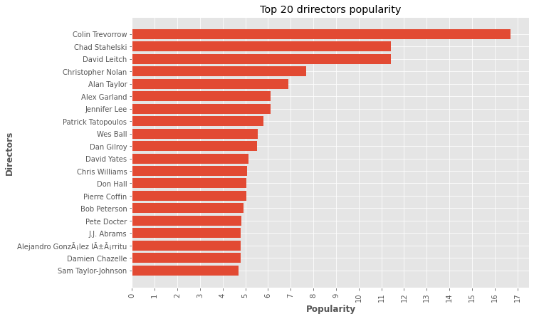

```python
plt.figure(figsize=(10,7))
y = top_20_popularity.popularity
x = top_20_popularity.director
plt.barh(x,y)
plt.xticks(np.arange(0,18,1))
plt.xticks(rotation=90)
plt.xlabel('Popularity',fontsize=12,fontweight='bold')
plt.ylabel('Directors',fontsize=12,fontweight='bold')
plt.title('Top 20 drirectors popularity')
plt.show()
```

> Her we visualize the top 20 popularity directors preparing to answer some questions later.

### Of the features you investigated, were there any unusual distributions? Did you perform any operations on the data to tidy, adjust, or change the form of the data? If so, why did you do this?

> I cleaned the data and pepared it for answer some quesions later in the upcoming secions.

## Bivariate Exploration

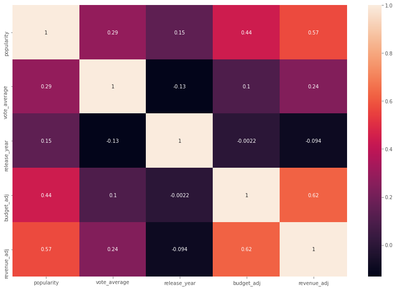

```python
# Spot the correlations between all columns
a , b = plt.subplots(figsize=(15, 10))
sb.heatmap(df.corr(), annot=True,ax=b)
plt.show()
```

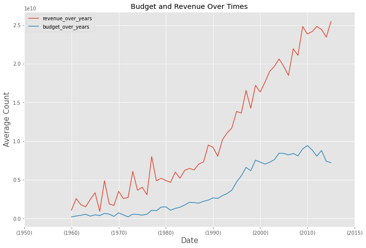

```python
# Plot the revenue_adj and budget_adj over Time
revenue_over_years = df.groupby(df.release_year).revenue_adj.sum()
budget_over_years = df.groupby(df.release_year).budget_adj.sum()
revenue_over_years.plot( figsize=(12,8),label='revenue_over_years')
budget_over_years.plot( figsize=(12,8),label='budget_over_years');
plt.xlabel('Date',fontsize=15)
plt.ylabel('Average Count',fontsize=15)
plt.title('Budget and Revenue Over Times')
plt.legend()
locs , labels = plt.xticks()
plt.xticks(locs , ( '(1950)','(1960)','(1970)','(1980)','(1990)','(2000)','(2010)','(2015)'));
```

> We can say that because of the popularity increasing over years the budget and revenues increases also.

### Talk about some of the relationships you observed in this part of the investigation. How did the feature(s) of interest vary with other features in the dataset?

> By the time , people's interest into movies increases alot so that the money spend to satisfy those people increases and the revenue from them for sure.

### Did you observe any interesting relationships between the other features (not the main feature(s) of interest)?

> we can say that the vote average can affect possitively on the popularity and the revenues

## Multivariate Exploration

> Create plots of three or more variables to investigate your data even further. Make sure that your investigations are justified, and follow from your work in the previous sections.

```python
# Find how many directors that in both [top 20 budgets & top 20 popularity] .
budget_popularity = list(top_20_popularity[top_20_popularity.budget_rank<=20].index)
budget_popularity = top_20_popularity[top_20_popularity.index.isin(budget_popularity)]
budget_popularity
```

|  | budget_rank | director | budget_adj | popularity | revenue_adj | vote_average | release_year |
| --- | --- | --- | --- | --- | --- | --- | --- |
| 14 | 11 | Bob Peterson | 1.778701e+08 | 4.908902 | 7.433371e+08 | 7.6 | 2009 |
| 10 | 8 | David Yates | 1.957563e+08 | 5.126634 | 1.044364e+09 | 7.4 | 2009 |

```python
# Find the top 20 revenues director
top_20_revenues = mean_director_data.sort_values(by=['revenue_adj'],ascending=False).head(20).reset_index()
top_20_revenues.rename(columns={'level_0':'budget_rank'},inplace=True)
top_20_revenues.sort_values(by=['revenue_adj'],inplace=True)
top_20_revenues
```

|  | budget_rank | director | budget_adj | popularity | revenue_adj | vote_average | release_year |
| --- | --- | --- | --- | --- | --- | --- | --- |
| 19 | 31 | Chris Miller | 1.471444e+08 | 1.466995 | 6.891215e+08 | 6.350000 | 2009 |
| 18 | 56 | Joss Whedon | 1.275730e+08 | 3.761224 | 6.948060e+08 | 7.425000 | 2010 |
| 17 | 10 | Dan Scanlon | 1.872067e+08 | 2.643496 | 6.959966e+08 | 7.000000 | 2013 |
| 16 | 252 | Kyle Balda | 6.728103e+07 | 4.543467 | 6.977506e+08 | 6.400000 | 2014 |
| 15 | 239 | Colin Trevorrow | 6.935612e+07 | 16.696886 | 6.981261e+08 | 6.600000 | 2014 |
| 14 | 18 | Robert Stromberg | 1.657964e+08 | 3.582315 | 6.985650e+08 | 7.000000 | 2014 |
| 13 | 20 | Conrad Vernon | 1.629166e+08 | 1.529965 | 7.196849e+08 | 6.300000 | 2008 |
| 12 | 756 | Wolfgang Reitherman | 3.115534e+07 | 2.222305 | 7.293424e+08 | 6.820000 | 1970 |
| 11 | 24 | Pete Docter | 1.601637e+08 | 4.813334 | 7.406167e+08 | 7.633333 | 2008 |
| 10 | 11 | Bob Peterson | 1.778701e+08 | 4.908902 | 7.433371e+08 | 7.600000 | 2009 |
| 9 | 78 | James Cameron | 1.145547e+08 | 3.202686 | 8.142180e+08 | 6.844444 | 1993 |
| 8 | 129 | Mike Thurmeier | 9.022571e+07 | 3.135776 | 8.331582e+08 | 6.200000 | 2012 |
| 7 | 238 | Pierre Coffin | 6.940617e+07 | 5.041612 | 8.387905e+08 | 6.866667 | 2013 |
| 6 | 17 | Raman Hui | 1.682670e+08 | 1.862295 | 8.402392e+08 | 5.800000 | 2007 |
| 5 | 37 | Lee Unkrich | 1.427148e+08 | 2.791537 | 8.540177e+08 | 7.350000 | 2003 |
| 4 | 8 | David Yates | 1.957563e+08 | 5.126634 | 1.044364e+09 | 7.400000 | 2009 |
| 3 | 180 | George Lucas | 7.829333e+07 | 3.910306 | 1.052320e+09 | 6.700000 | 1988 |
| 2 | 41 | Jennifer Lee | 1.404050e+08 | 6.112766 | 1.192711e+09 | 7.500000 | 2013 |
| 1 | 805 | Hamilton Luske | 2.917944e+07 | 2.631987 | 1.574815e+09 | 6.600000 | 1961 |
| 0 | 806 | Clyde Geronimi | 2.917944e+07 | 2.631987 | 1.574815e+09 | 6.600000 | 1961 |

```python
# Find how many directors that in both [top 20 budgets & top 20 revenues] .
budget_revenue = list(top_20_revenues[top_20_revenues.budget_rank<=20].index)
budget_revenue = top_20_revenues[top_20_revenues.index.isin(budget_revenue)]
budget_revenue
```

|  | budget_rank | director | budget_adj | popularity | revenue_adj | vote_average | release_year |
| --- | --- | --- | --- | --- | --- | --- | --- |
| 17 | 10 | Dan Scanlon | 1.872067e+08 | 2.643496 | 6.959966e+08 | 7.0 | 2013 |
| 14 | 18 | Robert Stromberg | 1.657964e+08 | 3.582315 | 6.985650e+08 | 7.0 | 2014 |
| 13 | 20 | Conrad Vernon | 1.629166e+08 | 1.529965 | 7.196849e+08 | 6.3 | 2008 |
| 10 | 11 | Bob Peterson | 1.778701e+08 | 4.908902 | 7.433371e+08 | 7.6 | 2009 |
| 6 | 17 | Raman Hui | 1.682670e+08 | 1.862295 | 8.402392e+08 | 5.8 | 2007 |
| 4 | 8 | David Yates | 1.957563e+08 | 5.126634 | 1.044364e+09 | 7.4 | 2009 |

```python
# Find the directors that in all Top 20 budget, revenue and popularity
budget_popularity_revenue = budget_revenue[budget_revenue.director.isin(budget_popularity.director)]
budget_popularity_revenue
```

|  | budget_rank | director | budget_adj | popularity | revenue_adj | vote_average | release_year |
| --- | --- | --- | --- | --- | --- | --- | --- |
| 10 | 11 | Bob Peterson | 1.778701e+08 | 4.908902 | 7.433371e+08 | 7.6 | 2009 |
| 4 | 8 | David Yates | 1.957563e+08 | 5.126634 | 1.044364e+09 | 7.4 | 2009 |

```python
plt.figure(figsize=(24,18),dpi=500)
# There is only two directors in both popularity and budget top 20 and we can visualize it
plt.subplot(1,2,1)
y1 = top_20_popularity.popularity
x1 = top_20_popularity.director
x2 = budget_popularity.director
y2 = budget_popularity.popularity
x3 = budget_popularity_revenue.director
y3 = budget_popularity_revenue.popularity
plt.barh(x1,y1,color='blue', label='top 20 popularity',)
plt.barh(x2,y2,color='red', label='drirectors in both Top 20 budget and popularity',)
plt.barh(x3,y3,color='green', label='drirectors in all Top 20 budget, revenue and popularity',)
plt.xticks(np.arange(0,21,1))
plt.xticks(rotation=90)
plt.legend(loc='best',fontsize=14)
plt.xticks(fontsize=12,fontweight='bold')
plt.yticks(fontsize=12,fontweight='bold')
plt.title("Director's Budget and Popularity",fontsize=20,fontweight='bold')
plt.xlabel('Popularity',fontsize=15,fontweight='bold')
plt.ylabel('Directors',fontsize=16,fontweight='bold')
# There is five directors in both revenue and budget top 20 and we can visualize it
plt.subplot(1,2,2)
y1 = top_20_revenues.revenue_adj
x1 = top_20_revenues.director
x2 = budget_revenue.director
y2 = budget_revenue.revenue_adj
x3 = budget_popularity_revenue.director
y3 = budget_popularity_revenue.revenue_adj
plt.barh(x1,y1,color='blue', label='top 20 revenue')
plt.barh(x2,y2,color='orange', label='drirectors in both Top 20 budget and revenues')
plt.barh(x3,y3,color='green', label='drirectors in all Top 20 budget, revenue and popularity',)
plt.xticks(np.arange(0,2000000000,200000000),['0','200M','400M','600M','800M','1B','1.2B','1.4B','1.6B','1.8B'])
plt.xticks(rotation=90)
plt.xticks(fontsize=12,fontweight='bold')
plt.yticks(fontsize=12,fontweight='bold')
plt.xlabel('Revenues',fontsize=15,fontweight='bold')
plt.legend(loc='lower right',fontsize=13)
plt.title("Director's Budget and Revenues",fontsize=20,fontweight='bold');
```

[figure not shown]

> From this figure we could analyse that from the main factors of the success as a director in most people's opinion which are the popularity and the revenues , we could notice that the budget is not the only factor to be successful as there is only two of the top 20 bubget spender who could be seucceful in our assumption so we can say that the big budget is not the only factor to success there is a lot of factors and i think that the most important one is the creativity.

### Talk about some of the relationships you observed in this part of the investigation. Were there features that strengthened each other in terms of looking at your feature(s) of interest?

> we could deeply understand the relationship betwwen the revenue and the budget most of times the budget affects positively on the revenues but on the other side to be one of the best you or the more you want to get high the the more budget effect decreases as there is lots of factor to be one of the best except the budget.

### Were there any interesting or surprising interactions between features?

> I think the analysis i gone as expected .